# Haywood County Assessment Analysis

Ori Baber

2022-08-01

# Sales Ratios

## Set Up

#### Step 1.1: Create a county specific folder in the GitHub repository

#### Step 1.2: Save the three necessary files into the folder– as .csv files

```
Naming convention:
    Assessment:   "county_name"_co_assessment_2021.csv
    Sales:        "county_name"_co_sales_2021.csv
    Appeals:      "county_name"_co_appeals_2021.csv
```

## Assessment Data

#### Step 2.1: Read the assessment file into the environment as a dataframe

```r
haywood_assessment<-read.csv("C:\\Users\\ori\\OneDrive\\Documents\\GitHub\\just_accounting\\sales_ratios_county\\haywood_co\\haywood_co_assessment_2021.csv", header=TRUE)

names(haywood_assessment)
```

```
##  [1] "ParcelID"                 "ParcelNumber"
##  [3] "BuildingCount"            "TownshipCode"
##  [5] "TaxExemptCode"            "ImprovementType"
##  [7] "ValuationModel"           "AccountNumber"
##  [9] "ParcelBuildingValue"      "ParcelObxfValue"
## [11] "ParcelLandValue"          "ParcelSpecialLandValue"
## [13] "ParcelDeferredValue"      "TotalAssessedValue"
## [15] "TotalMarketValue"         "HouseNumber"
## [17] "UnitNumber"               "StreetDirection"
## [19] "StreetName"               "StreetType"
## [21] "StreetSuffix"             "City"
## [23] "LegalDescription"         "LegalLandUnits"
## [25] "LegalLandType"            "Neighborhood"
## [27] "PlatBook"                 "PlatPage"
## [29] "ExemptionCode01"          "ExemptionCode02"
```

[output cut: 19 more lines]

#### Step 2.2: Identify unique land use classifications and select residential land uses.

The residential land uses that we include in this analysis are: single-family residential, townhouse, condos, manufacTRUEd homes. This field name could be a few different things— LandUseCode, LandUseDescription, ParcelUse, etc. You may need to consult the Schedule of Values for a data dictionary if there are only codes included in the file. You may need to validate the use codes against the proeprty card records on the County’s assessors office.

Write down the land use codes for residential here:

- Use Code D = Homesite Primary (Dwelling)
- Use Code CTT = Condo, Townhouse, Timeshare
- Use Code SW = Single Wide
- Use Code DW = Double Wide

```
land_class<-as.data.frame(unique(haywood_assessment$UseCode))

land_class
```

#### Step 2.3: Subset the full assessment dataframe to include just residential properties.

Also, reduce the fields to include only the parcel identification number and the market value. You many need to standardize the format of the PIN numbers (check sales section below). The final dataframe should include only residential properties, and only two field names: * PIN * assessed_value

*If you need to standardize the parcel identification number, use relevant pieces of this code: PIN=gsub(“-”, ““, PINN), ##removes dashes (most common transformation) PIN=sub(”^0+“,”“, PIN), ##remove leading zeros PIN=sub(”0+$“,”“, PIN))%>% ## remove trailing zeros*

```r
haywood_assessment_res_2021<-haywood_assessment%>%
  filter(UseCode %in% c("D", "CTT", "SW", "DW"), ## selects only residential properties
         ParcelBuildingValue != 0)%>% ## selects parcels with buildings (not vacant parcels)
  mutate(assessed_value=as.numeric(TotalMarketValue), ## renames the field names
         PIN=ParcelNumber)%>%
  select("PIN",  "assessed_value") ##select the only two fields need for this analysis
```

## Sales Data

#### Step 3.1: Read the sales file into the environment as a dataframe

```r
haywood_sales<-read.csv("C:\\Users\\ori\\OneDrive\\Documents\\GitHub\\just_accounting\\sales_ratios_county\\haywood_co\\haywood_co_sales_2021.csv", header=TRUE)

names(haywood_sales)
```

```
##  [1] "ParcelID"                 "ParcelNumber"
##  [3] "DeedBook"                 "DeedPage"
##  [5] "SaleMonth"                "SaleYear"
##  [7] "InstrumentType"           "VacantOrImproved"
##  [9] "QualifiedCode"            "SalePrice"
## [11] "DateQuestionnairePrinted" "TransferOrSplit"
## [13] "DeedDate"                 "DeedDateRaw"
## [15] "UserLastModified"         "DateLastModified"
## [17] "GrantorAccount"           "GrantorName"
## [19] "GranteeAccount"           "GranteeName"
## [21] "IsQualified"              "SalePricePerSqFt"
## [23] "IsReferencedSale"         "X"
## [25] "X.1"
```

#### Step 3.2: Subset the full sales dataframe to include only qualified, residential sales from 2021.

The final dataframe should only include:

- residential sales
- improved parcels (not vacant)
- qualified sales
- properties that have not had permitted improvements within the last year (this filter is a work in progress, TBD)

It’s common for the sales table to include both residential and commerical sales. It’s also common for the sales table to exclude a land use code. So we cross reference the residential assessment table to filter only residential sales.

```r
haywood_sales_res_2021<-haywood_sales%>%
  mutate(PIN=ParcelNumber, ##rename field names
         sale_price=SalePrice)%>%
  filter(SaleYear==2021,  ##filter only 2021 sales
         VacantOrImproved=="I", ##filter only improved (not vacant land) sales
         IsQualified=="True", ##fitler only qualified sales
         PIN %in% haywood_assessment_res_2021$PIN)%>% ##filter parcel numbers that exist in the residential assessment df
  select("PIN", "sale_price")
```

*Use this code if the data field is all weird and cannot be converted to a date, you can search just for ‘2021’:*

```r
  filter(grepl('2021', Sale.Date))
```

## Merge the Sales and Assessment Tables

#### Step 4.1: Merge tables.

```r
haywood_sales_assesment_2021<-merge(haywood_sales_res_2021, haywood_assessment_res_2021, by="PIN")
```

## Compute Sales Ratios

#### Step 5.1: Compute sales ratios and selling price decile. Summarise by selling price decile

```r
haywood_sales_assesment_2021_s<-haywood_sales_assesment_2021%>% ##Compute sales ratios
  na.omit()%>%
  mutate(selldecile = ntile(sale_price, 10),
         sale_ratio = assessed_value/sale_price)

haywood_sales_assesment_2021_s1<-haywood_sales_assesment_2021_s%>% ##Summarise by selling price decile
  group_by(selldecile) %>%
  summarise(sale_price = median(sale_price),
            sale_ratio = median(sale_ratio),
            count=sum(n()))
```

#### Step 5.1: Plot sales ratio analysis

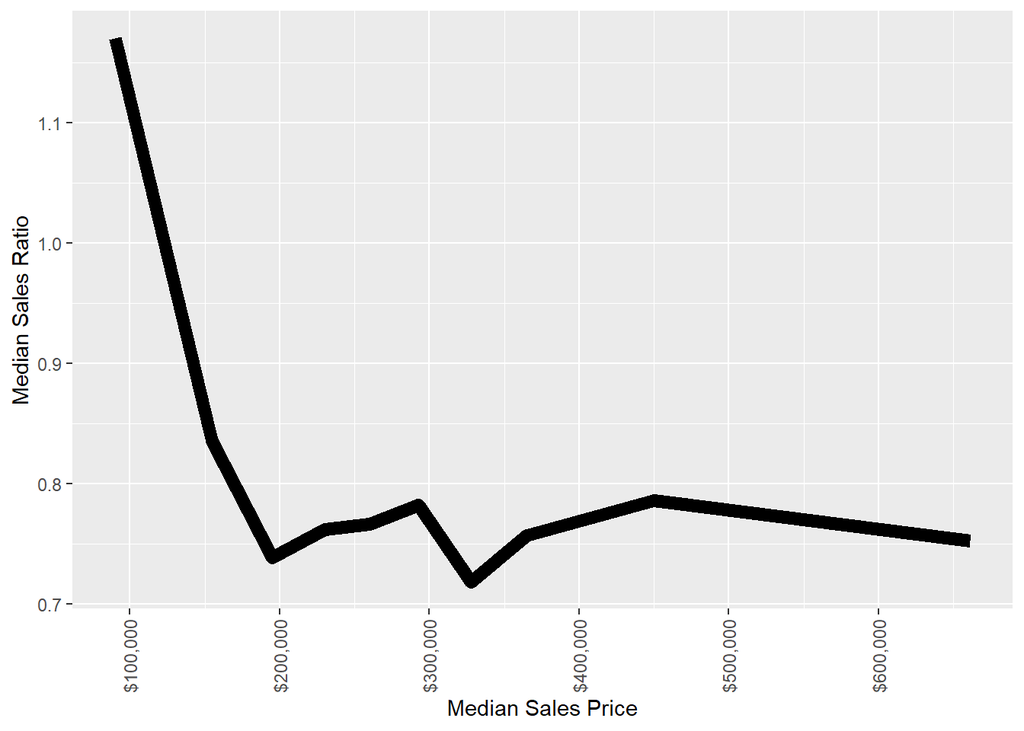

```r
haywood_sales_assesment_2021_s1_gg<-ggplot(data=haywood_sales_assesment_2021_s1, aes(x=sale_price, y=sale_ratio)) +
  geom_line(size=3)+
  scale_x_continuous(labels=scales::dollar_format())+
  theme(axis.text.x = element_text(angle = 90, vjust = 0.5, hjust=1))+
  xlab("Median Sales Price")+
  ylab("Median Sales Ratio")

haywood_sales_assesment_2021_s1_gg
```

# Value Distribution

#### Step 6.1: Filter high value outliers. Calculate median assessed value. Plot distribution.

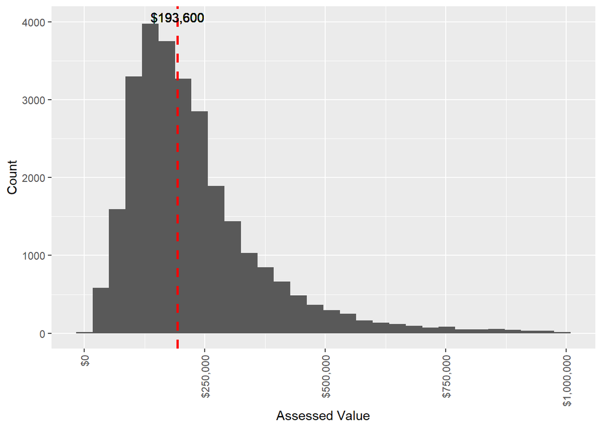

```r
haywood_assessment_res_2021_s<-haywood_assessment_res_2021%>%
  filter(assessed_value<1000000)

v_line<-median(haywood_assessment_res_2021_s$assessed_value)

haywood_assessment_res_2021_gg<-ggplot(haywood_assessment_res_2021_s, aes(x=assessed_value))+
  geom_histogram()+
  scale_x_continuous(labels=scales::dollar_format())+
  theme(axis.text.x = element_text(angle = 90, vjust = 0.5, hjust=1))+
  xlab("Assessed Value")+
  ylab("Count")+
  geom_vline(xintercept=median(haywood_assessment_res_2021_s$assessed_value), linetype="dashed", color="red", size=1)+
  geom_text(aes(v_line, 4000, label=scales::dollar(v_line), vjust=0)) ## update the vertical position of the median label with the second number

haywood_assessment_res_2021_gg
```

# Appeals

#### Step 7.1: Read the appeals file into the environment as a dataframe

```r
haywood_appeals<-read.csv("C:\\Users\\ori\\OneDrive\\Documents\\GitHub\\just_accounting\\sales_ratios_county\\haywood_co\\haywood_co_appeals_2021.csv", header=TRUE)

names(haywood_appeals)
```

```
##  [1] "AppealYear"                        "OwnerName1"
##  [3] "OwnerName2"                        "AppealType"
##  [5] "APP.LEVEL"                         "Parcel"
##  [7] "Appealed.Value"                    "ReasonForAppeal"
##  [9] "Date"                              "Informal...........Decision.Value"
## [11] "BOER.Decision.Value"
```

#### Step 7.2: Subset the full appeals dataframe to include only residential appeals from 2021.

```r
haywood_appeals_res_2021<-haywood_appeals%>%
  mutate(PIN=Parcel, ##rename parcel identification number
         PIN=gsub("-", "", PIN))%>% ##standardize PIN
  filter(PIN %in% haywood_assessment_res_2021$PIN) ##filter only residnetial appeals
```

#### Step 7.3: Calculate the quintiles of home values in the full residential dataframe.

```r
haywood_assessment_res_2021_s<-haywood_assessment_res_2021%>%
  mutate(ntile=ntile(assessed_value, 5))%>% ##Calculate quintiles
  group_by(ntile)%>%
  summarise(min=min(assessed_value),
            max=max(assessed_value),
            median=median(assessed_value),
            count=n())%>%
  na.omit()

break1<-haywood_assessment_res_2021_s[[1,3]]
break2<-haywood_assessment_res_2021_s[[2,3]]
break3<-haywood_assessment_res_2021_s[[3,3]]
break4<-haywood_assessment_res_2021_s[[4,3]]
count1<-haywood_assessment_res_2021_s[[1,5]]

haywood_appeals_res_2021_s<-haywood_appeals_res_2021%>%
  mutate(ntile=as.numeric(ifelse(Appealed.Value>=0 & Appealed.Value <break1, "1",
                          ifelse(Appealed.Value>=break1 & Appealed.Value< break2, "2",
                          ifelse(Appealed.Value>=break2 & Appealed.Value< break3, "3",
                          ifelse(Appealed.Value>=break3 & Appealed.Value< break4, "4", "5"))))))%>%
  group_by(ntile)%>%
  summarise(count=n())%>%
  mutate(participation_rate=count/count1)

haywood_appeals_summary<-merge(haywood_assessment_res_2021_s, haywood_appeals_res_2021_s, by="ntile")
```

#### Step 7.4 Plot Appeals Participation Rate

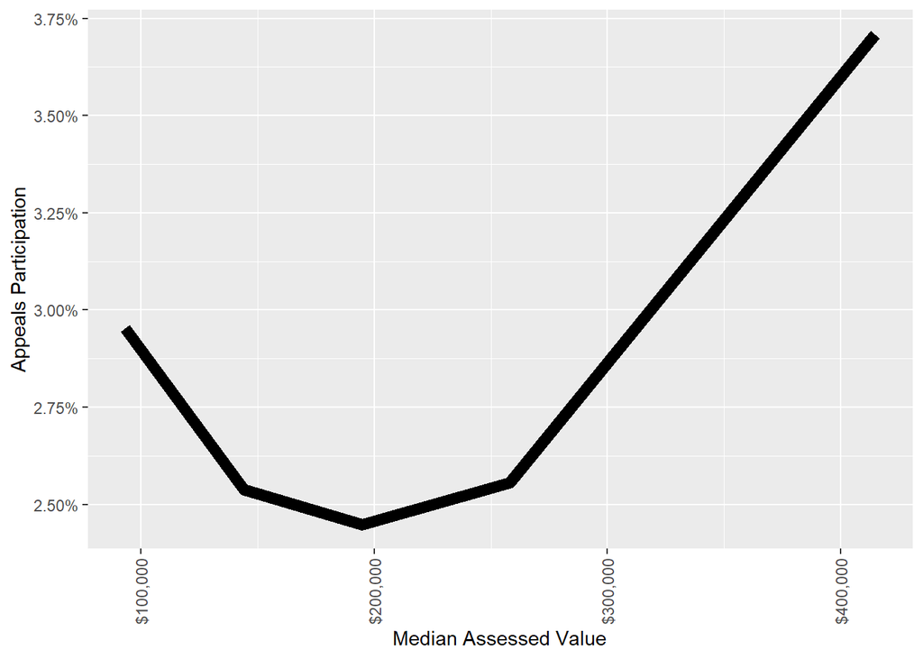

```r
haywood_appeals_summary_gg<-ggplot(data=haywood_appeals_summary, aes(x=median, y=participation_rate)) +
  geom_line(size=3)+
  scale_x_continuous(labels=scales::dollar_format())+
  scale_y_continuous(labels=scales::percent)+
  theme(axis.text.x = element_text(angle = 90, vjust = 0.5, hjust=1))+
  xlab("Median Assessed Value")+
  ylab("Appeals Participation")

haywood_appeals_summary_gg
```

# NCDOR Value of Real Property

#### Step 8.1: Read the value file into the environment as a dataframe.

```r
ncdor_value<-read.csv("C:\\Users\\ori\\OneDrive\\Documents\\GitHub\\just_accounting\\sales_ratios_county\\shared\\ncdor_real_value_by_county.csv", header=TRUE)
names(ncdor_value)<-c("County", "Residential", "Commercial", "Industrial", "Other", "Exemptions", "Total Taxable Value")
```

#### Step 8.2: Subset by County

```r
ncdor_value_county<-ncdor_value%>%
  mutate(County=str_squish(County),
         Residential=scales::dollar(Residential),
         Commercial=scales::dollar(Commercial),
         Industrial=scales::dollar(Industrial),
         Other=scales::dollar(Other),
         Exemptions=scales::dollar(Exemptions),
         `Total Taxable Value`=scales::dollar(`Total Taxable Value`))%>%
  filter(County==county_name)
```

#### Step 8.3: Plot table and figures

```r
kable(ncdor_value_county, caption="Value of Real Property")
```

Value of Real Property

| County | Residential | Commercial | Industrial | Other | Exemptions | Total Taxable Value |
| --- | --- | --- | --- | --- | --- | --- |
| HAYWOOD | $6,849,967,590 | $1,229,943,680 | NA | NA | $1,721,768,224 | $6,358,143,046 |